# Baltimore city’s Employee Dataset

2023-02-21

### **DECLARATION:** We, hereby, confirm that the below project represents our own work and that we have adhered to St. Clair College’s Academic Integrity policies in completing this project.

### **VERSION OF R & R-STUDIO** The version of R: 4.2.2 (2022-10-31 ucrt) The version of RStudio: 2022.12.0 (Build 353)

### **List of R packages used and their versions**

#### Package: tidyverse v1.3.2

#### Package: dplyr v1.0.10

#### Package: lubridate v1.9.0

#### Package: scales v1.2.1

#### Package: viridis v0.6.2

#### Package: RColorBrewer v1.1-3

#### Package: gganimate v1.0.8

#### Package: gifski v1.6.6-1

#### Package: transformr v0.1,4

#### Package: stringr v1.5.0

### **Documentation of the data sets:**

#### a. The Baltimore City Employee Salary (2011-2021) test data set used for this project is publicly available by the city administration.

#### b. The dataset link : https://data.baltimorecity.gov/datasets/baltimore::baltimore-city-employee-salaries-2/about

#### c. The dataset includes Baltimore City employee salaries and gross pay from fiscal year 2011 through last fiscal year and includes employees who were employed on June 30 of the last fiscal year. For fiscal years 2020 and prior, data are extracted from the ADP payroll system. For fiscal year 2021, the data are combined from the ADP system and the Workday enterprise resource planning system which now includes payroll.

### **Documentation of any changes made to the original data sets**

#### Manipulation of data can be found in the comment string of R CODE under ‘## Manipulating Data ##’ comment.

#### While exploring ‘## Manipulating Data ##’, you will find how we cleaned the data and used some of continuous variables into categorical and further grouped them for better insights of dataset.

### **External source references that was used by our team**

#### To build our animated plot using “gganimate”, we took references from following websites to know more about the arguments and process of building an animated plot for better representation

#### a. https://bookdown.org/yihui/rmarkdown-cookbook/figure-size.html

#### b. https://anderfernandez.com/en/blog/how-to-create-animations-in-r-with-gganimate/

### **The team’s opinion on the questions asked:**

### QUESTION 1. In what ways do you think data visualization is important to understanding a data set?

#### a. Data visualization is crucial in assisting the audience in better understanding the dataset by providing numerous visuals of the data with accurate trends and predictions.

#### b. A clear perspective is acquired about the importance of relations and trends in the dataset by mapping data to the appropriate business context.

#### c. It also aids in the time management of the concerned entity since examining the data visuals can help the audience obtain an understanding of the dataset in a comparatively shorter period of time.

### QUESTION 2. In what ways do you think data visualization is important to communicating important aspects of a data set?

#### Data visualization is crucial in understanding any dataset as it provides with

#### a. Insights of current data

#### b. Relations in the dataset

#### d. Background of data and its observations

#### Gaining such aspects will further help the decision-makers and concerned entities with predicting future trends and improving business decisions/outcomes.

### QUESTION 3. What role does your integrity as an analyst play when creating a data visualization for communicating results to others?

#### Data visualizations provided by us (Data Analysts) to the audience should depict true integrity ensuring that the data processed is in line with the original dataset and should provide meaningful and relative information and trends.

### QUESTION 4. How many variables do you think you can successfully represent in a visualization? What happens when you exceed this number?

#### Visualization of a dataset to represent any information is usually processed with multiple variables (i.e, data visualization is multivariate). To depict data in a visual form in a meaningful manner, generally, a maximum of 4 variables can be used. If we exceed this number during visualization, it may lead to a chaotic representation with too many data points to differentiate between and will lead to an unclear image of what exactly the data is depicting.

```r
######Import data, package installation and calling libraries#########
bal_cit_data <- read.csv("C:/Users/ikram/OneDrive/Documents/DAB_501/Baltimore_City_Project/Baltimore_City_Employee_Salaries.csv")
library(tidyverse)                     #Package: tidyverse v1.3.2
library(dplyr)                         #Package: dplyr v1.0.10
library(lubridate)                     #Package: lubridate v1.9.0
#install.packages("scales")
library(scales)                        #Package: scales v1.2.1
#install.packages("viridis")
library("viridis")                     #Package: viridis v0.6.2
#install.packages("RColorBrewer")
library(RColorBrewer)                  #Package: RColorBrewer v1.1-3
#install.packages("gganimate")
library(gganimate)                     #Package: gganimate v1.0.8
library(gifski)                        #Package: gifski v1.6.6-1
#install.packages("transformr")
library(transformr)                    #Package: transformr v0.1,4
library(stringr)                       #Package: stringr v1.5.0
```

```r
# Documentation of any changes made to the original data sets

######Manipulating Data######
options(scipen = 999)
#bal_cit_data
ncol(bal_cit_data)
```

```
## [1] 11
```

```r
nrow(bal_cit_data)
```

```
## [1] 154187
```

```r
bal_cit_data_frame <-data.frame(bal_cit_data)

#Cleaning data
bal_cit_data_frame_new<-bal_cit_data_frame[is.na(as.numeric(bal_cit_data_frame$middleInitial)),]
bal_cit_data_frame_final <- bal_cit_data_frame_new[!is.na(bal_cit_data_frame_new$hireDate),]
bal_cit_data_frame_final$hireDate<-as.Date(bal_cit_data_frame_final$hireDate)
bal_cit_data_frame_final$hire_year <- format(bal_cit_data_frame_final$hireDate,format= "%Y")
bal_cit_data_frame_final$hire_year <- as.numeric(format(bal_cit_data_frame_final$hireDate,format= "%Y"))

#changing HireDate into categorical variable : Hire range
breaks <- c(1900,1970,1981,1992,2003,2014,2025)
bal_cit_data_frame_final$bin_range <- cut(bal_cit_data_frame_final$hire_year,breaks,labels=c("1900-1969","1970-1980","1981-1991","1992-2002","2003-2013","2014-2024"),include.lowest = TRUE)

#Removing 'FY' from the Fiscal Year data
bal_cit_data_frame_final$fiscalYear <- as.factor(gsub("FY","",bal_cit_data_frame_final$fiscalYear))

#Generating Annual Salary categorical variable
annual_break <- c(0,35000,70000,105000,140000,280000)
bal_cit_data_frame_final$annual_range <- cut(bal_cit_data_frame_final$annualSalary,annual_break,labels=c("Very Low","Low","Medium","High","Very High"),include.lowest = TRUE)

#Generating Gross Salary categorical variable
bal_cit_data_frame_final$grossPay <-round(bal_cit_data_frame_final$grossPay, digits = 0)
gross_breaks <- c(0,35000,70000,105000,140000,373111)
bal_cit_data_frame_final$gross_range <- cut(bal_cit_data_frame_final$grossPay,gross_breaks,labels=c("verylow","low","medium","High","very High"),include.lowest = TRUE)

#Generating Sectors/categories from Agencies
defence  <- c('A99','A64','A38','A54','A11','BPD','A08','A51','A26','A57','R01','D01')
public_works <- c('A50','A90','A04','A06','A49','B70','A67','C90','A70','A41','B49','A84','A68','B68','P04')
govt <- c('A03','A29','A31','A75','A40','A09','A30','A10','A01','A91','A02','A37','A33','A52','W07','A73','A35','A28','A86')
others <- c('A85','A83','A19','A46','A39','W08','W03','SCS','A51','A44','P83','U01','A65','P65')
finance <- c('A24','A17','A32','A15','A14','A23','A18','A16','A12','A88','A53')

bal_cit_data_frame_final$sector <-
  as.factor(ifelse(bal_cit_data_frame_final$agencyID %in% defence, 'defence',
                     ifelse(bal_cit_data_frame_final$agencyID %in% public_works, 'public_works',
                     ifelse(bal_cit_data_frame_final$agencyID %in% govt, 'govt',
                     ifelse(bal_cit_data_frame_final$agencyID %in% others, 'others','finance')))))

#Creating additional data frame by excluding Hire_year : 1900(Outlier)
bal_cit_data_frame_filter <- filter(bal_cit_data_frame_final, hire_year != 1900)
```

```r
#Creating theme for reusing it in graphs
mynamestheme <- theme(
  plot.title = element_text(family = "serif", face = "bold", size = (20),colour = "blue4"),
  legend.title = element_text(colour = "blue", face = "bold", family = "serif",size = (15)),
  legend.text = element_text(face = "italic", colour = "blue4", family = "serif",size = (12)),
  axis.title = element_text(family = "serif", size = (15), colour = "blue4"),
  axis.text = element_text(family = "mono", colour = "blue1", size = (14)),
  legend.box.background = element_rect(fill='grey50'),
  plot.background = element_rect(fill='transparent', color='grey50'),
  plot.caption = element_text(family = "serif", size = (13), colour = "black")
)
```

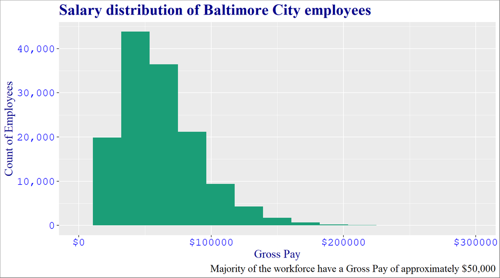

```r
#Two plots with single CONTINUOUS variable
ggplot(bal_cit_data_frame_final) + geom_histogram(mapping = aes(x= grossPay,fill = 'red'),bins = 15) + scale_fill_brewer(type = "diverging", palette = 'Dark2') + mynamestheme + ggtitle("Salary distribution of Baltimore City employees") + labs(y= "Count of Employees", x = "Gross Pay", caption = "Majority of the workforce have a Gross Pay of approximately $50,000") + scale_x_continuous(labels =comma_format(decimal.mark = ","),scales::dollar_format()) + scale_y_continuous(labels=comma_format(decimal.mark = ",")) + theme(legend.position = "none") + scale_x_continuous(limits = c(0, 300000), label = function(x) paste0("$", x))
```

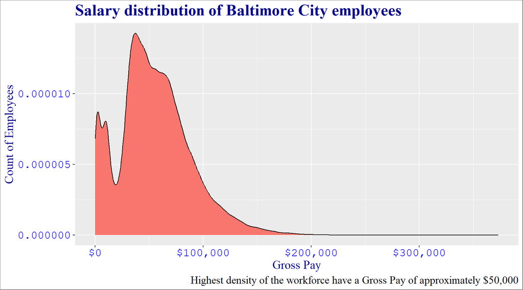

```r
ggplot(bal_cit_data_frame_final) + geom_density(mapping = aes(x= grossPay, fill = 'blue')) + mynamestheme + ggtitle("Salary distribution of Baltimore City employees") + labs(y= "Count of Employees", x = "Gross Pay",caption = "Highest density of the workforce have a Gross Pay of approximately $50,000") + scale_x_continuous(labels =comma_format(decimal.mark = ","),scales::dollar_format()) + scale_x_continuous(labels=scales::dollar_format()) + theme(legend.position = "none")
```